# Homework 10

Katarzyna Kanska

17.12.2015

## Goal

For the `eunomia` study perform following analyses:

- Try a post-hoc test for effect of `ICD10` to find out which diseases are more likely to produce psychotic behaviours?
- Is it possible you cluster `ICD10` groups depending on average level of psychotic behaviours?
- Is it possible to do something similar if `ICD10` is coded as random effects?

## Post-hoc test (`ICD10` as fixed effect)

We are focusing on variable `BPRS.T1`, that is average score for Brief Psychiatric Rating Scale, measured in time T1. Here we explain it using variable `ICD10` (International Statistical Classification of Diseases and Related Health Problems) treated as fixed effect.

Firstly we analyse the results of LSD post-hoc test.

```r
library(PBImisc)
library(agricolae)
(groups1 <- (LSD.test(aov(BPRS.T1 ~ ICD10, data=eunomia),"ICD10"))$groups)
```

```
##       trt    means     M
## 1   F34.9 4.416667     a
## 2   F12.1 3.916667    ab
## 3   F63.9 3.652174   abc
## 4   F04.0 3.291667  abcd
## 5   F60.1 3.135417  abcd
## 6   F38.0 3.083333  abcd
## 7   F72.0 3.041667 abcde
## 8   F20.8 2.998492  bcde
## 9   F10.8 2.937500  bcde
## 10  F23.  2.916667 bcdef
## 11  F42.0 2.886364 bcdef
## 12  F22.9 2.718750 bcdef
## 13  F13.3 2.666667 bcdef
## 14  F30.2 2.661458 bcdef
```

[output cut: 124 more lines]

```r
table(groups1[,3])
```

```
##
##     a    ab   abc  abcd abcde  bcde bcdef  cdef   def    ef     f
##     1     1     1     3     1     2     6    17    51    35    20
```

Note that the `BPRS` have values ranging from 1 (not present) to 7 (extremely severe psychotic disorders). So we are interested in diseases with relatively high mean of `BPRS`.

Variable `ICD10` have 138 levels, so it hard to set a proper threshold for deciding whether each disease has significantly higher mean of `BPRS` than other diseases. Therefore it could be beneficial to reduce number of `ICD10` levels. At the moment we can only say that `F34.9` has the highest mean.

## Clusterization (`ICD10` as fixed effect)

We try to cluster `ICD10` groups using the results of LSD post-hoc test. But this is not very satisfying result as we see 6 overlapping subgroups (called from “a” to “f”). Maybe adding another variable (`NUM.HOSP` - number of hospitalizations) would help somehow. Let’s see.

```r
groups2 <- (LSD.test(aov(BPRS.T1 ~ NUM.HOSP + ICD10, data=eunomia),"ICD10"))$groups
table(groups2[,3])
```

```
##
##      a     ab    abc   abcd    bcd   bcde  bcdef bcdefg  cdefg   defg
##      1      1      1      1      2      3      3      1     12     47
##    efg     fg      g
##     34     12     20
```

Now we have 7 groups which is slightly better result. But still any group cannot be distinguished from other ones.

But we won’t give up that easily. We can try clustering group of `ICD10` levels that have the same set of letters (although there is no straight justification for doing it this way).

```r
eunomia$ICD10new <- as.character(eunomia$ICD10)

for (x in levels(groups2$M)){
  for (y in unlist(lapply(groups2$trt[groups2$M == x], as.character))){
    eunomia$ICD10new[eunomia$ICD10 == y] <- paste0("F.", x)
  }
}

eunomia$ICD10new <- factor(eunomia$ICD10new)

groups3 <- (LSD.test(aov(BPRS.T1 ~ NUM.HOSP + ICD10new, data=eunomia),"ICD10"))$groups
table(groups3[,3])
```

```
##
##    a   ab  abc abcd  bcd bcde  cde   de    e
##    1    1    1    1    3    1    1    1    3
```

Now we can iterate this procedure.

```r
eunomia$ICD10new2 <- as.character(eunomia$ICD10new)

for (x in levels(groups3$M)){
  for (y in gsub(" ", "", unlist(lapply(groups3$trt[groups3$M == x], as.character)), fixed = TRUE)){
    eunomia$ICD10new2[eunomia$ICD10new == y] <- paste0("F2.", x)
  }
}

eunomia$ICD10new2 <- factor(eunomia$ICD10new2)

groups4 <- (LSD.test(aov(BPRS.T1 ~ NUM.HOSP + ICD10new2, data=eunomia),"ICD10"))$groups
table(groups4[,3])
```

```
##
##    a   ab  abc abcd  bcd bcde  cde   de    e
##    1    1    1    1    1    1    1    1    1
```

There is no further possibility for clustering using this method. But let’s see what we derived.

```r
groups4
```

```
##       trt    means    M
## 1 F2.a    4.416667    a
## 2 F2.ab   3.916667   ab
## 3 F2.abc  3.652174  abc
## 4 F2.abcd 3.291667 abcd
## 5 F2.bcd  2.971372  bcd
## 6 F2.bcde 2.666667 bcde
## 7 F2.cde  2.568326  cde
## 8 F2.de   2.307340   de
## 9 F2.e    1.931553    e
```

Still it is not clear what the threshold should be. By the rule of thumb we can say that 3 first groups have higher probability of having stronger psychotic behaviours. (Because their mean is above the middle point of the `BPRS` scale (that is 3.5).)

Now let’s “decode” these artificial groups.

F2.a stands for

```r
as.character(groups2$trt[groups2$M==gsub(" ", "",gsub("F.", "", groups3$trt[groups3$M=="a"], fixed = TRUE), fixed = TRUE)])
```

```
## [1] "F34.9"
```

F2.ab stands for

```r
as.character(groups2$trt[groups2$M==gsub(" ", "",gsub("F.", "", groups3$trt[groups3$M=="ab"], fixed = TRUE), fixed = TRUE)])
```

```
## [1] "F12.1"
```

F2.abc stands for

```r
as.character(groups2$trt[groups2$M==gsub(" ", "",gsub("F.", "", groups3$trt[groups3$M=="abc"], fixed = TRUE), fixed = TRUE)])
```

```
## [1] "F63.9"
```

So our selected diseases are `F34.9`, `F12.1` and `F63.9 3.652174`, which could have been derived from the first LSD test result as well…

Maybe the model diagnostics is better for the clustered variable?

```r
shapiro.test(rstandard(lm(BPRS.T1 ~ NUM.HOSP + ICD10, data=eunomia)))
```

```
##
##  Shapiro-Wilk normality test
##
## data:  rstandard(lm(BPRS.T1 ~ NUM.HOSP + ICD10, data = eunomia))
## W = 0.9682, p-value < 2.2e-16
```

```r
shapiro.test(rstandard(lm(BPRS.T1 ~ NUM.HOSP + ICD10new2, data=eunomia)))
```

```
##
##  Shapiro-Wilk normality test
##
## data:  rstandard(lm(BPRS.T1 ~ NUM.HOSP + ICD10new2, data = eunomia))
## W = 0.96476, p-value < 2.2e-16
```

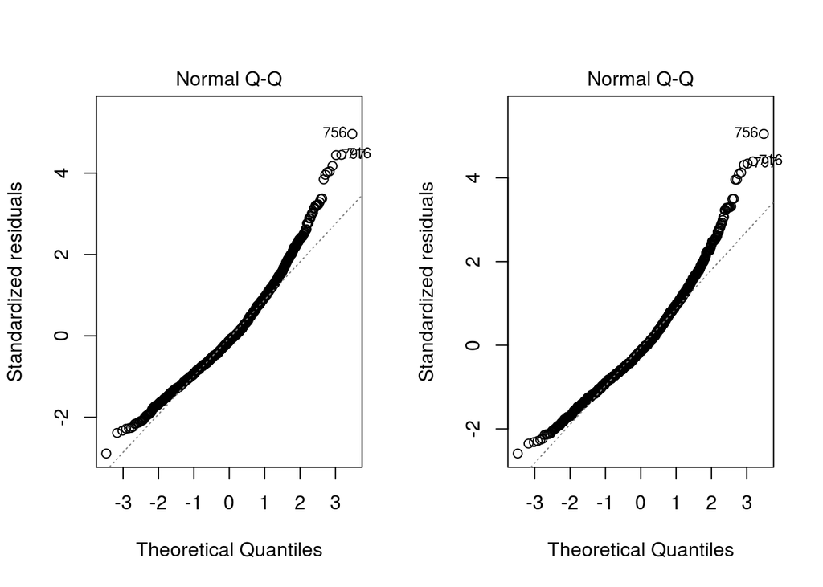

```r
par(mfrow=c(1,2))
plot(lm(BPRS.T1 ~ NUM.HOSP + ICD10, data=eunomia), which=2)
plot(lm(BPRS.T1 ~ NUM.HOSP + ICD10new2, data=eunomia), which=2)
```

There is not much difference.

## Clusterization (`ICD10` as random effect)

If we treat `ICD10` as a random effect for the mean, then we won’t get any information which would be useful for clusterization. The only way to vary some subgroups of `ICD10` is assuming that it has a different effect depending on the number of hospitalizations.

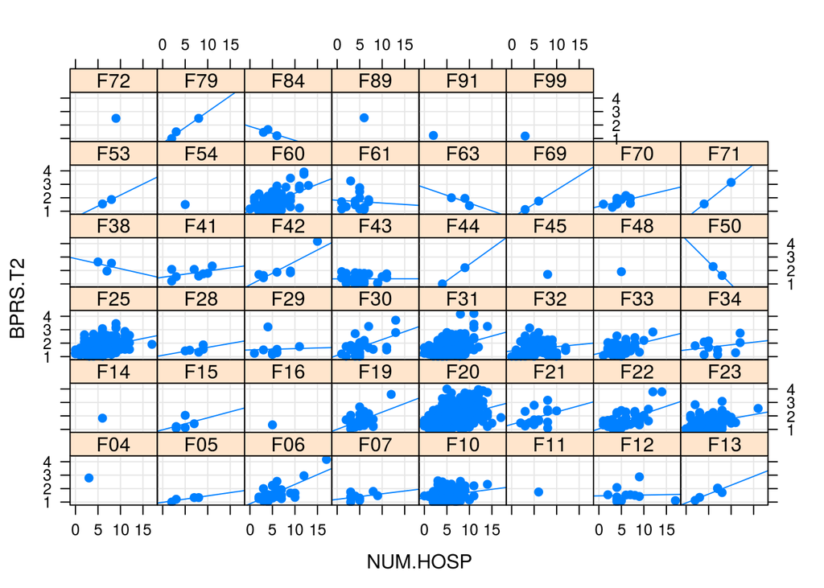

```r
library(lme4)
library(lattice)

ICD10new3 <- substr(eunomia$ICD10, start=0, stop=3)
eunomiaNEW <- data.frame(eunomia, ICD10new3)

xyplot(BPRS.T2 ~ NUM.HOSP | ICD10new3, eunomiaNEW, type = c("g","p","r"), pch=19)
```

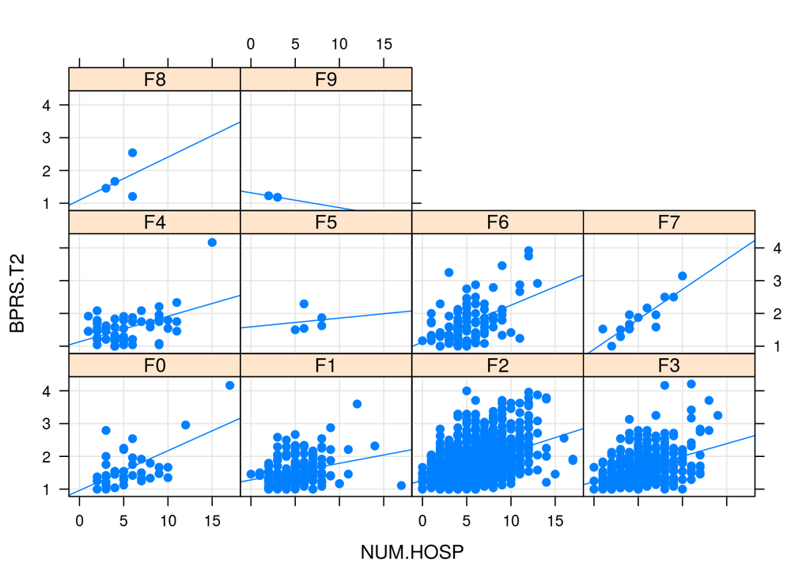

```r
ICD10new4 <- substr(eunomia$ICD10, start=0, stop=2)
eunomiaNEW2 <- data.frame(eunomia, ICD10new4)

xyplot(BPRS.T2 ~ NUM.HOSP | ICD10new4, eunomiaNEW2, type = c("g","p","r"), pch=19)
```

There is some evidence of different slopes.

```r
(model <- lmer(BPRS.T2 ~ NUM.HOSP + (NUM.HOSP | ICD10), eunomia))
```

```
## Linear mixed model fit by REML ['lmerMod']
## Formula: BPRS.T2 ~ NUM.HOSP + (NUM.HOSP | ICD10)
##    Data: eunomia
## REML criterion at convergence: 2650.814
## Random effects:
##  Groups   Name        Std.Dev. Corr
##  ICD10    (Intercept) 0.15649
##           NUM.HOSP    0.04374  -0.92
##  Residual             0.45599
## Number of obs: 2008, groups:  ICD10, 138
## Fixed Effects:
## (Intercept)     NUM.HOSP
##     1.23070      0.08064
```

Some kind of “post-hoc test for mixed model” would be very helpful here.